# 2 Storing data: Vectors

Author

Vladimir Buskin

## 2.1 Suggested reading

- Gries (2013: Chapter 2)
- James et al. (2021: Chapter 2.3)
- Winter (2019: Chapter 1)

## 2.2 Word frequencies I

You are given the following token counts of English verb lemmas in the International Corpus of English:

| Lemma | Frequency |
| --- | --- |
| start | 418 |
| enjoy | 139 |
| begin | 337 |
| help | 281 |

It is always a good idea to visualise frequency data in some way. Quite conveniently, R happens to provide us with an abundance of plotting functions. To create a two-dimensional plot, we need to generate two objects in R: one for the individual lemmas and one for the frequency counts.

Let’s combine the lemmas *start, enjoy, begin* and *help* using R’s `c()` function and store them in an object `lemma`. Enter the following line into a new R script and click on **Run** (or simply press Ctrl+Enter/Cmd+Enter).

```r
lemma <- c("start", "enjoy", "begin", "help")
```

We can now do the same for the frequency information:

```r
frequency <- c(418, 139, 337, 281)
```

**When do I use quotation marks?**

Letters and numbers represent two distinct data types in R. Anything that should be understood as a simple sequence of letters or words must be enclosed by quotation marks `"..."`. An expression such as `start` will then be evaluated as a **string**.

**Numbers** (or **integers**), by contrast, appear without quotation marks.

Our linguistic data is now stored in two **variables** `lemma` and `frequency`, which you can conceptualise as virtual container-like objects. You will also notice that they are now showing in the **Environment** tab in the top right corner of RStudio.

The combination of categorical labels and numeric information renders our data ideally suited for a barplot. R’s most basic barplot function (which is, unsurprisingly, simply called `barplot()`) needs at the very least …

- a `height` argument, i.e., our y-axis values and
- a `names.arg` argument, i.e., our x-axis label.

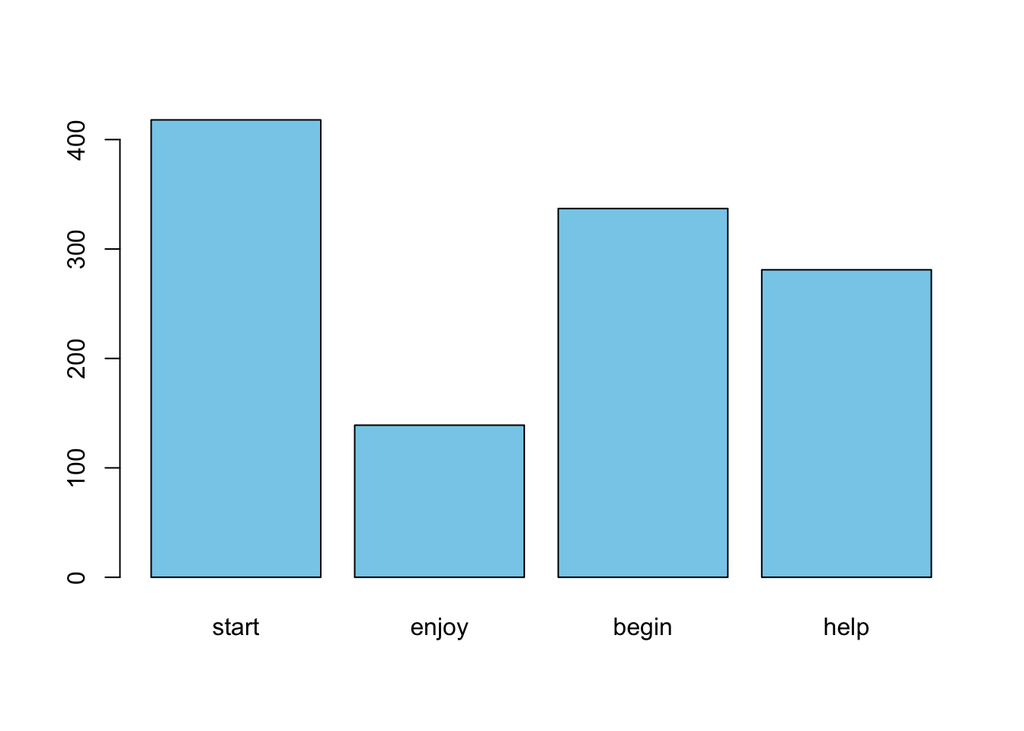

```r
barplot(frequency, names.arg = lemma, col = "skyblue")
```

After some tinkering, our plot looks more presentable:

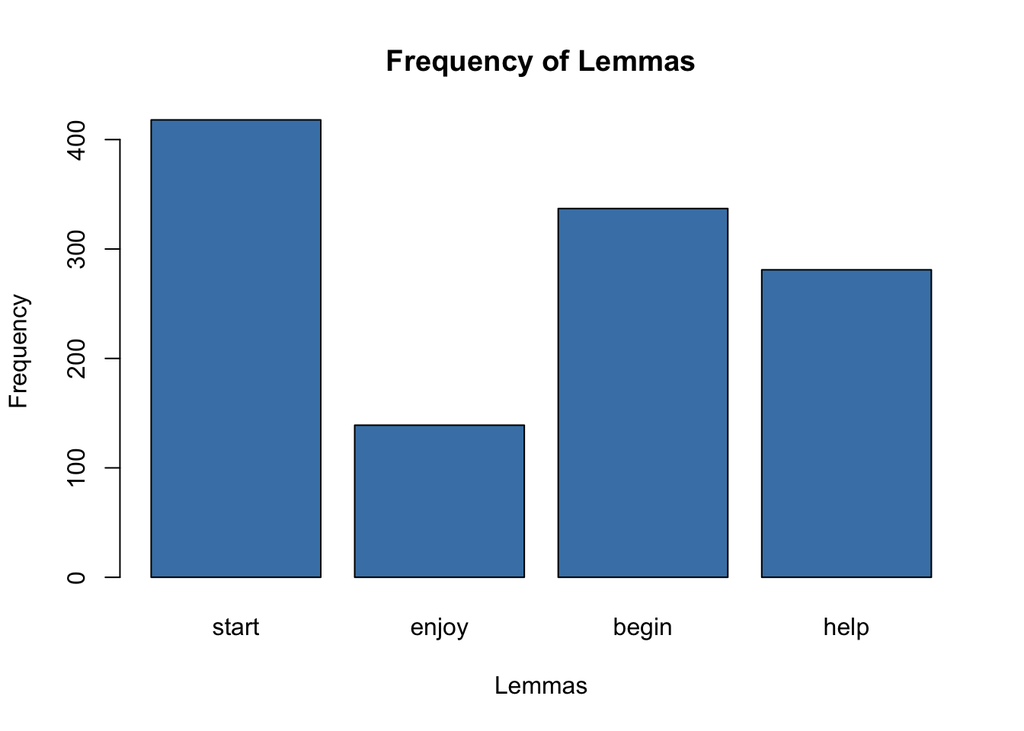

```r
barplot(frequency, names.arg = lemma,
        main = "Frequency of Lemmas", # title
        xlab = "Lemmas",  # label for x-axis
        ylab = "Frequency", # label for y-axis
        col = "steelblue") # color
```

**What does ‘#’ mean? On comments in R**

In R, everything followed by the hashtag `#` will be interpreted as a comment and won’t be evaluated by the R compiler. While comments don’t affect the output of our code in the slightest, they are **crucial** to any kind of programming project.

Adding prose annotations to your code will make not only it easier to understand for others but also for your future self. Poor documentation is a common, yet unnecessary source of frustration for all parties involved …

[figure not shown]

## 2.3 Functions and arguments

**Description**

- To call or invoke a built-in function in R you write the name of the function and then enter its argument values enclosed in parentheses and separated by commas.
- **Pattern**: $\text{function}(\text{argument}_1, \text{argument}_2, ..., \text{argument}_n)$ which translates to ‘apply the function to argument$_1$, argument$_2$, …, argument$_n$’.
- **Example**: The `seq()` function produces arithmetic sequences:

```r
seq(from = 1, to = 9, by = 2)
```

```
[1] 1 3 5 7 9
```

- Every function has a default order for the arguments. If you provide arguments in this order, then they do not need to be named.

```r
seq(1, 9, 2)
```

```
[1] 1 3 5 7 9
```

**Some useful functions**

- `c()` to combine numbers or character strings into a vector

```r
# Concatenate the numbers 1, 2 and 3 into vector "a"
a <- c(1, 2, 3)

# Print "a"
a
```

```
[1] 1 2 3
```

- `class()` and `str()` to inspect the structure of objects

```r
class(a)
```

```
[1] "numeric"
```

```r
str(a)
```

```
 num [1:3] 1 2 3
```

- `rm()` to remove objects from the working environment

```r
rm(a)
```

## 2.4 Variables

- Variables are similar to **folders**: they can be filled with information, inspected, and changed.
- To assign a value to a variable we use the **assignment command** `<-`.

```r
# Assign the value 100 to the variable x
x <- 100

# Print the content of x
print(x)
```

```
[1] 100
```

```r
# or simply:
x
```

```
[1] 100
```

- The variables currently stored are displayed in the **Environment** tab. You can also list them in the console with `ls()`.

## 2.5 Vectors

**Generating vectors**

- In R, vectors are **indexed lists of variables**. They can be generated with the functions `c()`, `seq()` and `rep()`.

```r
# Define a character vector "vehicles"
vehicles <- c("car", "truck", "bus")

# Print the content of vehicles
vehicles
```

```
[1] "car"   "truck" "bus"
```

- We can access the `i`-th element of a vector `x` using the notation `x[i]`.

```r
# Access the first element of vehicles
vehicles[1]
```

```
[1] "car"
```

**Editing vectors**

- View content of one or several indexed positions

```r
# View the first two elements
vehicles[1:2]
```

```
[1] "car"   "truck"
```

- Where in the vector does a specific property apply?

```r
vehicles == "bus"
```

```
[1] FALSE FALSE  TRUE
```

- Do multiple properties apply?

```r
c("truck", "bus") %in% vehicles
```

```
[1] TRUE TRUE
```

- What positions do certain elements occupy in a vector?

```r
match(c("truck", "bus"), vehicles)
```

```
[1] 2 3
```

## 2.6 Factors

**Generating factors**

- First, generate a vector such as

```r
articles <- c("a", "the", "a", "a", "a", "the", "the")
```

- Convert the vector to a factor using the `factor()` function:

```r
articles <-  factor(articles)
```

- Inspect the contents of the factor

```r
articles
```

```
[1] a   the a   a   a   the the
Levels: a the
```

- Check the levels of “articles”

```r
levels(articles)
```

```
[1] "a"   "the"
```

**Editing factors**

- Change the reference level of a factor:

```r
# Prior to changing the reference level
levels(articles)
```

```
[1] "a"   "the"
```

```r
# Changing the reference level
articles <- relevel(articles, ref = "the")

levels(articles)
```

```
[1] "the" "a"
```

- Change a factor level:

```r
# Change level "the" to "def_art" (definite article)
levels(articles)[1] <- "def_art"

# Change level "a" to "indef_art" (indefinite article)
levels(articles)[2] <- "indef_art"
```

```r
# Print "articles"
print(articles) # the original levels "the" and "a" have been replaced
```

```
[1] indef_art def_art   indef_art indef_art indef_art def_art   def_art
Levels: def_art indef_art
```

- Change factor back to a character/numeric vector using `as.character()`or `as.numeric()`:

```r
articles <- as.character(articles)

str(articles)
```

```
 chr [1:7] "indef_art" "def_art" "indef_art" "indef_art" "indef_art" ...
```